# Ski jump distance forecasting - GAM model

Wiktor Florek

12 06 2021

# Introduction and objectives

One of the brightest aims while creating this ski jumping database was:

*Can I use this data to sensible future prediction of distances achieved by the athletes?*

I have a strong feeling that the answer is affirmative, because we have a lot of credible predictors like

- tangential wind speed
- inrun speed / start gate height
- ratings system, which measure the long-time potential of every jumper

et cetera. Of course these factors alone still leave a substantial amount of variance and that is an information which is known to every ski jumping fan - *every minor or unobserved change can cause a huge difference in final distance*. We can express this property simply as the quasi-chaotic behavior of our target variable. Therefore we must be aware of the fact that the technique used has to handle these subtleties.

# Our basic approach - linear regression and Generalized Addivite Model (GAM)

First we will use an obvious base model - linear regression (without any penalties on the coefficients, because we have a huge amount of data to process and overfitting should not be present).

To make this introduction concise, [here](https://www.kaggle.com/wrotki8778/nyc-airbnb-price-modeling-by-gam) you have my markdown with an example of using GAM and its theoretical foundation. To our purpose the most important is to know that GAM is a hybrid of generalized linear models (like logistic or linear regression) and polynomial regression. GAM allows to capture nonlinear dependencies between predictors and the target variable, also (with some restrictions) using interactions between predictors.

# Data preparation

The necessary point is to clean and pre-process our dataset to be used in GAM:

```r
all_ratings <- read.csv("all_ratings.csv")
all_comps_r <- read.csv("all_comps_r.csv")
all_results <- read.csv("all_results.csv")
all_names <- read.csv("all_names.csv")
all_names <- all_names[!duplicated(all_names[,c('codex')]),]
all_results <- all_results[all_results['speed']>50 & all_results['speed']<115,]
all_results <- all_results[all_results['dist']>40,]
dataset <- merge(all_results,all_comps_r,by=c('id'),all.y=FALSE)

dataset['norm_dist'] = dataset['dist']/dataset['hill_size_x']
dataset <- merge(dataset,all_ratings,by.x=c('id','codex.x','round'),by.y=c('id','codex','round'),all.y=FALSE,all.x=TRUE)
dataset$gender = as.integer(as.factor(dataset$gender))
dataset$date_new = as.integer(as.Date.character(dataset$date))
train_dataset = dataset[(dataset['season']>2010) & (dataset['season']>2016),]
```

Dataset called *dataset* has a lot of variables, but we will use only columns called:

- *norm_dist* – normalized distance of an athlete and our target variable (1 means that our jumper achieved hill size of an object),
- *speed* – raw speed of an athlete in km/h,
- *wind* – the mean tangential speed of wind (negative values correspond with tail wind, positive – with head wind),
- *hill_size_x* – the hill size of an underlying object, where the competition is held,
- *cumm_rating* – rating of an athlete (1000 is the average, the bigger the better)
- *gender* – 0/1 variable indicating men or ladies competition,
- *date_new* – integer indicating day of the competition (reformatted from the standard time scale to be able to included in GAM)
- *training* – 0/1 variable indicating training rounds.

One specific column is worth to mention, because it appears the first time in our dataset:

- *short_rating* – variable computed by the following method: take all previous jumps (training or competition) in the underlying weekend, calculate their deltas (i.e. see if the results of these are better or worse than the general level suggest) and take the mean.

# Results - linear regression

Let’s see how the basic linear regression model behaves:

```r
simple_model <- lm(norm_dist~speed+wind+hill_size_x+cumm_rating+gender+date_new+training+short_rating, data=train_dataset)
summary(simple_model)
```

```
##
## Call:
## lm(formula = norm_dist ~ speed + wind + hill_size_x + cumm_rating +
##     gender + date_new + training + short_rating, data = train_dataset)
##
## Residuals:
##      Min       1Q   Median       3Q      Max
## -0.54257 -0.03286  0.00537  0.03994  0.40251
##
## Coefficients:
##                Estimate Std. Error  t value Pr(>|t|)
## (Intercept)  -2.218e-01  1.064e-02  -20.839  < 2e-16 ***
## speed         1.304e-02  1.102e-04  118.358  < 2e-16 ***
## wind          2.858e-02  2.610e-04  109.496  < 2e-16 ***
## hill_size_x  -2.579e-03  1.697e-05 -151.967  < 2e-16 ***
## cumm_rating   2.187e-04  7.911e-07  276.379  < 2e-16 ***
## gender       -4.561e-02  2.532e-04 -180.127  < 2e-16 ***
## date_new      2.626e-06  3.627e-07    7.238 4.57e-13 ***
## training     -1.787e-02  3.723e-04  -48.007  < 2e-16 ***
## short_rating  3.456e-03  3.469e-05   99.637  < 2e-16 ***
## ---
## Signif. codes:  0 '***' 0.001 '**' 0.01 '*' 0.05 '.' 0.1 ' ' 1
##
## Residual standard error: 0.06211 on 113818 degrees of freedom
##   (12463 observations deleted due to missingness)
## Multiple R-squared:  0.531,  Adjusted R-squared:  0.5309
## F-statistic: 1.611e+04 on 8 and 113818 DF,  p-value: < 2.2e-16
```

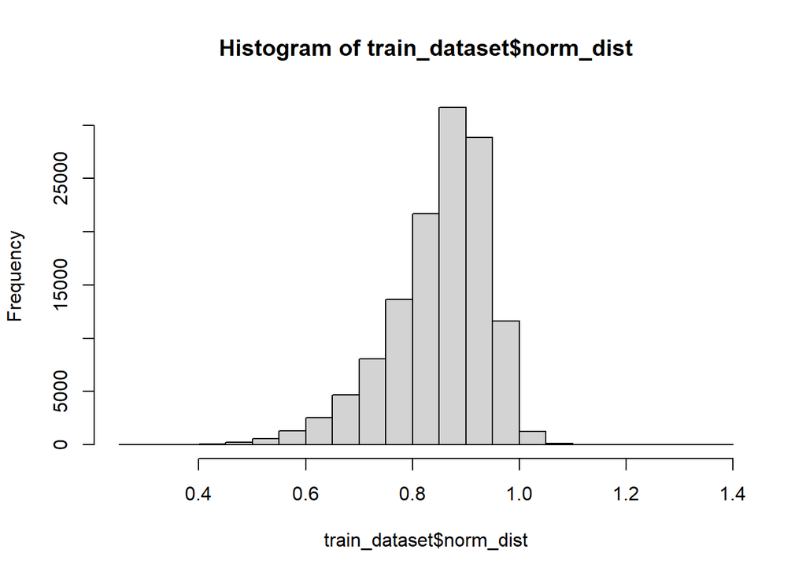

```r
hist(train_dataset$norm_dist)
```

We can ask *OK, but what do these results mean when we try to make the real predictions?* To answer that question we will check the predictions of our model in the following 3 cases:

1. World Cup in Trondheim in 2017 (code 2017JP3817RL), which was pretty standard competition without any major weather surprises and other problems.
2. World Ski Championships on Normal Hill in Seefeld in 2019 (code 2019JP3192RL), which was exactly the opposite of the first case, so it can be a good benchmark of robustness of our model,
3. Ski Flying World Cup in Kulm in 2018 (code 2018JP3068RL), where we will check the behavior on flying events.

Now we will create appropriate test set and see how well our linear model generalizes:

```r
require(tidyverse)
require(knitr)
codes = c('2017JP3817RL','2019JP3192RL','2018JP3068RL')
predict_comp <- function(code, dataset, model){
  test_dataset = dataset %>% filter(grepl(code, id)) %>% arrange(desc(cumm_rating),round)
  test_dataset = merge(test_dataset, all_names,how='left',by.x='codex.x',by.y='codex')
  test_dataset['prediction'] = predict(model,test_dataset)*test_dataset['hill_size_x']
  test_dataset['prediction'] = round(2*test_dataset['prediction'])/2
  test_dataset['error'] = test_dataset['dist'] - test_dataset['prediction']
  kable(test_dataset[,c('name','round','cumm_rating','short_rating','dist','prediction','error')])
}
for(code in codes) print(predict_comp(code,dataset,simple_model))
```

```
##
##
## |name                     |round       | cumm_rating| short_rating|  dist| prediction| error|
## |:------------------------|:-----------|-----------:|------------:|-----:|----------:|-----:|
## |kasai noriaki            |final round |   1444.9038|    6.2088979| 128.0|      132.0|  -4.0|
## |kasai noriaki            |1st round   |   1433.7662|    1.2801642| 130.0|      129.5|   0.5|
## |ammann simon             |final round |   1441.1074|    9.6047339| 127.0|      132.5|  -5.5|
## |ammann simon             |1st round   |   1433.1410|   10.1508499| 133.5|      134.0|  -0.5|
## |bresadola davide         |final round |   1254.8586|    1.2848157| 128.5|      124.5|   4.0|
## |bresadola davide         |1st round   |   1248.2192|   -0.5000475| 124.0|      122.0|   2.0|
## |fettner manuel           |1st round   |   1568.4992|    4.1365346| 128.0|      134.5|  -6.5|
## |fettner manuel           |final round |   1567.2824|    1.4599045| 134.0|      134.5|  -0.5|
## |matura jan               |1st round   |   1201.1267|   -8.7213526| 120.0|      116.0|   4.0|
## |descombes sevoie vincent |final round |   1462.7116|    7.4740731| 127.5|      134.0|  -6.5|
## |descombes sevoie vincent |1st round   |   1456.6217|    7.9354798| 129.5|      132.5|  -3.0|
## |damjan jernej            |final round |   1357.1463|    1.5591402| 125.0|      124.5|   0.5|
## |damjan jernej            |1st round   |   1349.3274|   -0.5274550| 128.0|      125.0|   3.0|
## |kofler andreas           |1st round   |   1427.4735|  -11.2034200| 124.0|      123.0|   1.0|
## |kofler andreas           |final round |   1422.9008|   -9.5457541| 123.5|      125.5|  -2.0|
## |colloredo sebastian      |1st round   |   1224.1996|    4.7907699| 117.0|      124.0|  -7.0|
## |wank andreas             |final round |   1352.5704|   -4.5288204| 124.5|      124.0|   0.5|
## |wank andreas             |1st round   |   1348.7240|   -7.3205473| 127.0|      123.5|   3.5|
## |ito daiki                |final round |   1543.2963|    5.1138647| 128.5|      136.5|  -8.0|
## |ito daiki                |1st round   |   1537.6102|    4.9231040| 132.0|      136.5|  -4.5|
## |stoch kamil              |final round |   1715.3688|    4.7631045| 137.0|      140.0|  -3.0|
## |stoch kamil              |1st round   |   1710.5898|    4.7578159| 139.5|      141.0|  -1.5|
## |zyla piotr               |1st round   |   1627.1437|   -0.2615769| 128.5|      134.5|  -6.0|
## |zyla piotr               |final round |   1625.2064|   -0.6805105| 125.5|      134.0|  -8.5|
## |takeuchi taku            |1st round   |   1370.6865|   -0.2960427| 119.5|      126.0|  -6.5|
## |boyd-clowes mackenzie    |1st round   |   1268.1646|    0.7355157| 123.5|      126.0|  -2.5|
## |koudelka roman           |final round |   1445.9616|   -4.1798774| 132.5|      126.5|   6.0|
## |koudelka roman           |1st round   |   1437.3906|   -8.4301706| 130.0|      125.0|   5.0|
## |kubacki dawid            |1st round   |   1499.7934|  -12.1564644| 123.5|      125.5|  -2.0|
## |stjernen andreas         |final round |   1601.8421|    7.6287382| 138.0|      139.0|  -1.0|
## |stjernen andreas         |1st round   |   1591.1820|    6.6182932| 138.5|      138.5|   0.0|
## |eisenbichler markus      |final round |   1673.1242|    5.7841439| 140.0|      140.5|  -0.5|
## |eisenbichler markus      |1st round   |   1666.0726|    5.3616561| 141.0|      139.5|   1.5|
## |leihe stephan            |1st round   |   1501.6334|  -12.2596362| 126.5|      125.5|   1.0|
## |leihe stephan            |final round |   1497.6928|  -10.1798729| 121.5|      125.5|  -4.0|
## |hayboeck michael         |1st round   |   1640.1281|    6.1990129| 124.0|      138.5| -14.5|
```

[output cut: 182 more lines]

```
## |wolny jakub           |1st round   |    1310.405|   -3.0311982| 175.5|      175.5|   0.0|
## |kobayashi ryoyu       |final round |    1375.831|    0.9422502| 184.0|      182.5|   1.5|
## |kobayashi ryoyu       |1st round   |    1376.376|    1.3139334| 195.5|      183.5|  12.0|
## |jelar ziga            |1st round   |    1370.623|    8.4447263| 177.0|      189.0| -12.0|
## |bartol tilen          |1st round   |    1417.587|   10.1300414| 190.5|      190.5|   0.0|
## |bartol tilen          |final round |    1413.905|    7.3676145| 206.5|      190.5|  16.0|
## |bickner kevin         |final round |    1241.512|    4.5327043| 196.5|      181.5|  15.0|
## |bickner kevin         |1st round   |    1238.192|    4.8359075| 189.5|      180.0|   9.5|
## |wellinger andreas     |1st round   |    1735.702|   -2.1232366| 196.0|      199.5|  -3.5|
## |wellinger andreas     |final round |    1727.348|   -3.3693985| 211.5|      202.5|   9.0|
## |insam alex            |1st round   |    1231.124|   -0.2599403| 189.5|      176.5|  13.0|
## |granerud halvor egner |final round |    1438.807|   -0.5285169| 184.5|      185.0|  -0.5|
## |granerud halvor egner |1st round   |    1438.481|   -0.7420596| 195.0|      186.0|   9.0|
## |prevc domen           |final round |    1430.051|   14.0639677| 211.0|      200.0|  11.0|
## |prevc domen           |1st round   |    1422.727|   15.7490685| 205.0|      196.5|   8.5|
```

The basic thoughts about the results can be as below:

# Results - GAM

Now we will try the more advanced model, when the non-linearity is present:

```r
library(mgcv) # contains our prime model
model<-gam(norm_dist~s(speed)+wind+hill_size_x+s(cumm_rating)+gender+training+s(date_new)+s(short_rating), data=train_dataset)
summary(model)
```

```
##
## Family: gaussian
## Link function: identity
##
## Formula:
## norm_dist ~ s(speed) + wind + hill_size_x + s(cumm_rating) +
##     gender + training + s(date_new) + s(short_rating)
##
## Parametric coefficients:
##               Estimate Std. Error t value Pr(>|t|)
## (Intercept)  1.377e+00  2.959e-03  465.44   <2e-16 ***
## wind         3.075e-02  2.567e-04  119.80   <2e-16 ***
## hill_size_x -3.446e-03  2.121e-05 -162.47   <2e-16 ***
## gender      -5.277e-02  2.708e-04 -194.88   <2e-16 ***
## training    -1.775e-02  5.005e-04  -35.46   <2e-16 ***
## ---
## Signif. codes:  0 '***' 0.001 '**' 0.01 '*' 0.05 '.' 0.1 ' ' 1
##
## Approximate significance of smooth terms:
##                   edf Ref.df       F p-value
## s(speed)        8.996  9.000  2277.4  <2e-16 ***
## s(cumm_rating)  8.967  9.000 10115.0  <2e-16 ***
## s(date_new)     8.970  9.000   151.1  <2e-16 ***
## s(short_rating) 7.288  8.323  1156.1  <2e-16 ***
## ---
## Signif. codes:  0 '***' 0.001 '**' 0.01 '*' 0.05 '.' 0.1 ' ' 1
##
## R-sq.(adj) =  0.576   Deviance explained = 57.6%
## GCV = 0.0034915  Scale est. = 0.0034903  n = 113827
```

The results suggest that the further development of the model increased the explained variance from 53% to 57.5%. Now we will check how it projects on the predictions phase:

```
## [1] "0.453709082943647 0.437624273670331"
```

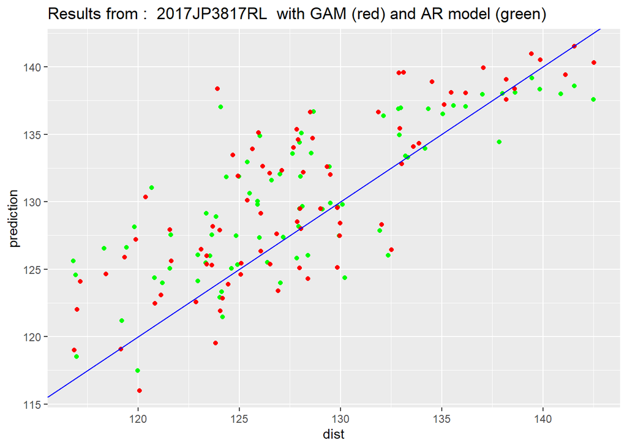

```
##                        name        round  dist linear_prediction linear_error
## 1             kasai noriaki final round  128.0             132.0         -4.0
## 2             kasai noriaki   1st round  130.0             129.5          0.5
## 3              ammann simon final round  127.0             132.5         -5.5
## 4              ammann simon   1st round  133.5             134.0         -0.5
## 5          bresadola davide final round  128.5             124.5          4.0
## 6          bresadola davide   1st round  124.0             122.0          2.0
## 7            fettner manuel   1st round  128.0             134.5         -6.5
## 8            fettner manuel final round  134.0             134.5         -0.5
## 9                matura jan   1st round  120.0             116.0          4.0
## 10 descombes sevoie vincent final round  127.5             134.0         -6.5
## 11 descombes sevoie vincent   1st round  129.5             132.5         -3.0
## 12            damjan jernej final round  125.0             124.5          0.5
## 13            damjan jernej   1st round  128.0             125.0          3.0
## 14           kofler andreas   1st round  124.0             123.0          1.0
```

[output cut: 148 more lines]

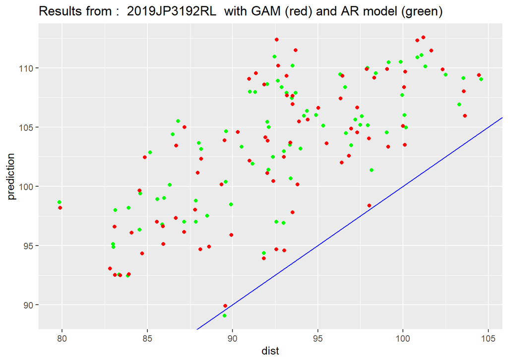

```
##                     name        round  dist linear_prediction linear_error
## 1           ammann simon   1st round   93.0             102.5         -9.5
## 2           ammann simon final round  100.0             105.0         -5.0
## 3      vassiliev dimitry final round   96.5             102.0         -5.5
## 4      vassiliev dimitry   1st round   92.5             100.5         -8.0
## 5          damjan jernej final round   98.0             104.0         -6.0
## 6          damjan jernej   1st round   92.0             104.0        -12.0
## 7    colloredo sebastian final round   93.5              98.0         -4.5
## 8    colloredo sebastian   1st round   92.5              94.5         -2.0
## 9              ito daiki   1st round   89.5             104.0        -14.5
## 10           stoch kamil   1st round   91.5             109.5        -18.0
## 11           stoch kamil final round  101.5             111.5        -10.0
## 12           hula stefan   1st round   88.0             102.5        -14.5
## 13           hula stefan final round  100.0             103.5         -3.5
## 14            zyla piotr   1st round   90.5             104.5        -14.0
```

[output cut: 142 more lines]

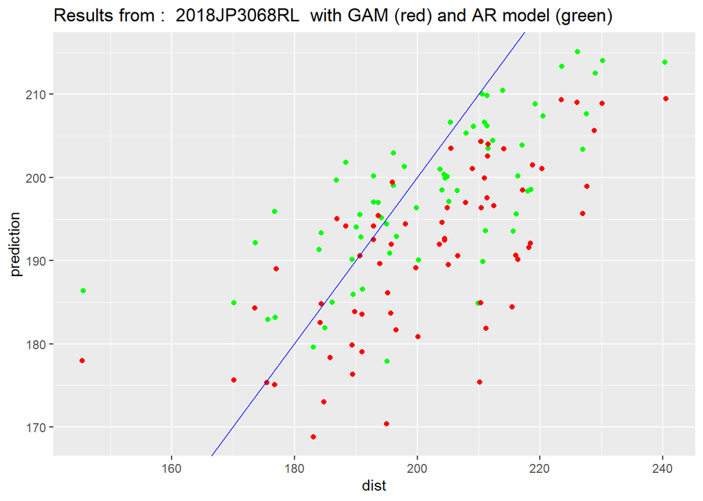

```
##                     name        round  dist linear_prediction linear_error
## 1           ahonen janne   1st round  170.0             175.5         -5.5
## 2          kasai noriaki final round  227.0             195.5         31.5
## 3          kasai noriaki   1st round  216.0             190.5         25.5
## 4           ammann simon final round  227.5             199.0         28.5
## 5           ammann simon   1st round  218.0             191.5         26.5
## 6           paschke pius   1st round  191.0             183.5          7.5
## 7           paschke pius final round  190.0             184.0          6.0
## 8          damjan jernej   1st round  218.5             192.0         26.5
## 9    colloredo sebastian   1st round  177.0             175.0          2.0
## 10          wank andreas   1st round  145.5             178.0        -32.5
## 11           stoch kamil   1st round  193.5             195.5         -2.0
## 12           stoch kamil final round  193.0             194.0         -1.0
## 13           hula stefan   1st round  208.0             197.0         11.0
## 14           hula stefan final round  210.5             196.5         14.0
```

[output cut: 123 more lines]

```r
require(tidyverse)
require(knitr)
require(ggplot2)
predict_comp_two <- function(code, dataset, simple_model, model){
  test_dataset = dataset %>% filter(grepl(code, id)) %>% arrange(desc(cumm_rating),round)
  test_dataset = merge(test_dataset, all_names,how='left',by.x='codex.x',by.y='codex')
  test_dataset['linear_prediction'] = predict(simple_model,test_dataset)*test_dataset['hill_size_x']
  test_dataset['linear_prediction'] = round(2*test_dataset['linear_prediction'])/2
  test_dataset['prediction'] = predict(model,test_dataset)*test_dataset['hill_size_x']
  test_dataset['prediction'] = round(2*test_dataset['prediction'])/2
  test_dataset['linear_error'] = test_dataset['dist'] - test_dataset['linear_prediction']
  test_dataset['error'] = test_dataset['dist'] - test_dataset['prediction']
  r_squared_gam = sum((test_dataset[,'error'])^2)/sum((test_dataset[,'dist']-mean(test_dataset[,'dist']))^2)
  r_squared_linear = sum((test_dataset[,'linear_error'])^2)/sum((test_dataset[,'dist']-mean(test_dataset[,'dist']))^2)
  print(paste(1-r_squared_gam, 1-r_squared_linear))
  N = paste('Results from : ', code, ' with GAM (red) and AR model (green)')
  print(ggplot(test_dataset) + geom_jitter(aes(x = dist, y = prediction), color='green') + geom_jitter(aes(x = dist, y = linear_prediction), color='red') + geom_abline(aes(intercept=0,slope=1), color='blue') + labs(title=N))
  output = test_dataset[,c('name','round','dist','linear_prediction','linear_error','prediction','error')]
  return(output)
}
for(code in codes) print(predict_comp_two(code,dataset,simple_model,model))
```

We can see that the biggest difference can be seen on the flying hills, but the problems remain similar.

# How we can try to improve the quality of our model?

I have been thought about these results and the basic explanation of the problems with our model can be as below:

The target variable is not only *jumper-dependent*, but also (if not mainly) *time-dependent*, i.e. the actual model errors should be positively correlated if the moment of jumps are similar.

If we introduce the time-dependency to our model, then most of our problems should be removed. How can we do that?

# Autoregressive (AR) prediction model

Before the code, I want to describe the basic equation of our model:

where $\hat{L}_t$ is the predicted normalized length of the $t$-th jumper, $\epsilon_i = L_i - GAM_i$ is the *actual* error caused by the GAM approximation until time $t$ and $GAM_t$ is the GAM prediction of $L_t$.

```
## [1] "0.532062428093272 0.457964137436854"
```

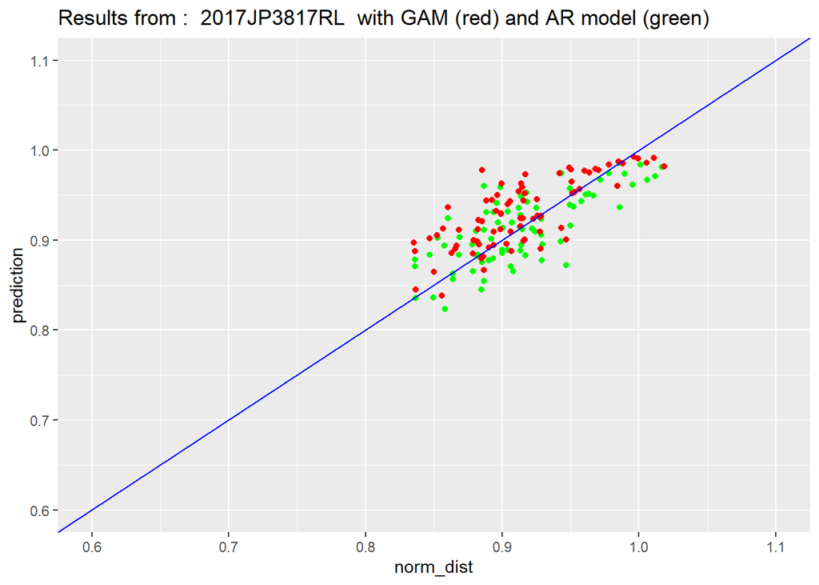

```
##                        name        round  dist gam_t epsilon_t prediction error
## 1             kasai noriaki   1st round  130.0 129.6       0.4      129.3   0.7
## 2             kasai noriaki final round  128.0 132.2      -4.2      128.1  -0.1
## 3              ammann simon   1st round  133.5 133.5       0.0      131.2   2.3
## 4              ammann simon final round  127.0 132.1      -5.1      128.7  -1.7
## 5          bresadola davide   1st round  124.0 123.4       0.6      119.7   4.3
## 6          bresadola davide final round  128.5 126.0       2.5      123.7   4.8
## 7            fettner manuel final round  134.0 134.0       0.0      132.1   1.9
## 8            fettner manuel   1st round  128.0 134.3      -6.3      132.8  -4.8
## 9                matura jan   1st round  120.0 117.4       2.6      115.3   4.7
## 10 descombes sevoie vincent final round  127.5 133.5      -6.0      131.0  -3.5
## 11 descombes sevoie vincent   1st round  129.5 132.3      -2.8      131.0  -1.5
## 12            damjan jernej final round  125.0 125.3      -0.3      123.1   1.9
## 13            damjan jernej   1st round  128.0 125.9       2.1      124.4   3.6
## 14           kofler andreas final round  123.5 125.3      -1.8      123.7  -0.2
```

[output cut: 67 more lines]

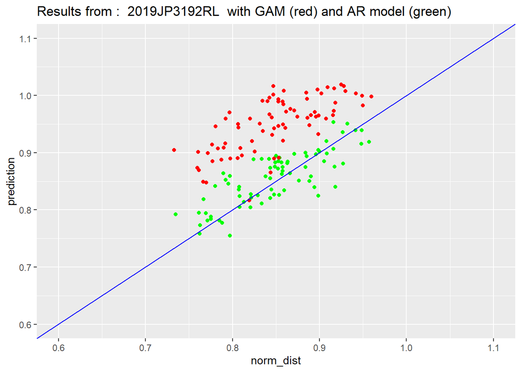

```
##                     name        round  dist gam_t epsilon_t prediction error
## 1           ammann simon final round  100.0 106.1      -6.1       98.8   1.2
## 2           ammann simon   1st round   93.0 103.2     -10.2       90.0   3.0
## 3      vassiliev dimitry   1st round   92.5 102.7     -10.2       90.1   2.4
## 4      vassiliev dimitry final round   96.5 104.7      -8.2       98.1  -1.6
## 5          damjan jernej final round   98.0 105.2      -7.2       98.6  -0.6
## 6          damjan jernej   1st round   92.0 105.4     -13.4       93.2  -1.2
## 7    colloredo sebastian   1st round   92.5  97.0      -4.5       97.5  -5.0
## 8    colloredo sebastian final round   93.5 100.4      -6.9       94.0  -0.5
## 9              ito daiki   1st round   89.5 104.6     -15.1       90.2  -0.7
## 10           stoch kamil final round  101.5 109.9      -8.4      103.6  -2.1
## 11           stoch kamil   1st round   91.5 107.9     -16.4       93.6  -2.1
## 12           hula stefan final round  100.0 105.2      -5.2       91.6   8.4
## 13           hula stefan   1st round   88.0 103.6     -15.6       89.8  -1.8
## 14            zyla piotr   1st round   90.5 103.6     -13.1       90.0   0.5
```

[output cut: 64 more lines]

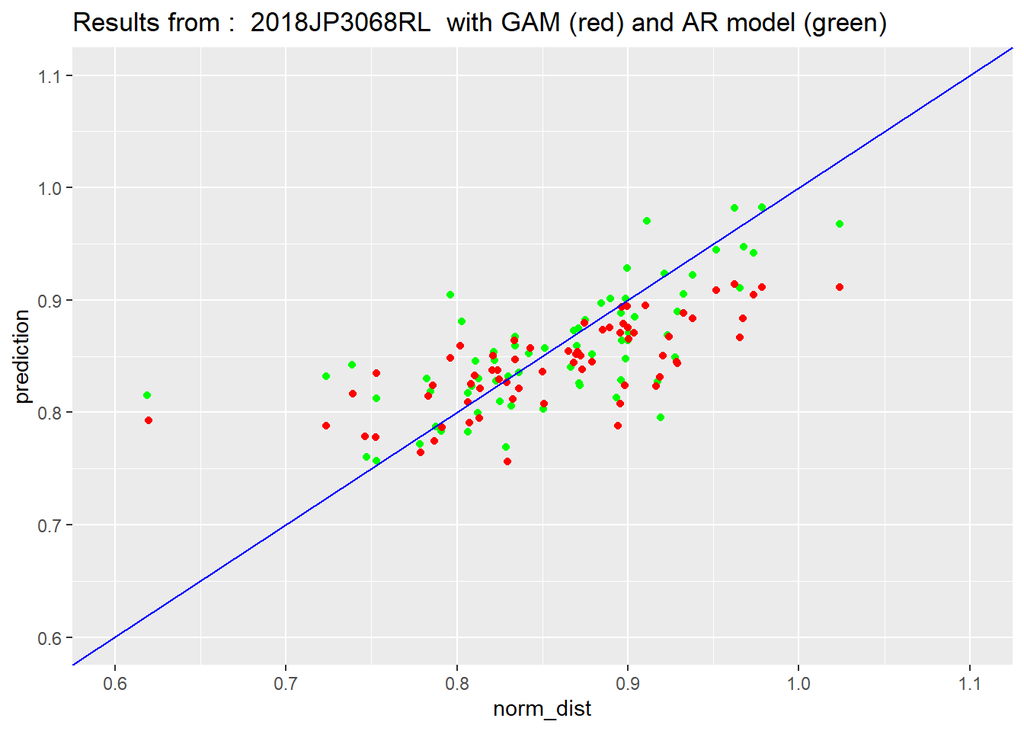

```
##                     name        round  dist gam_t epsilon_t prediction error
## 1           ahonen janne   1st round  170.0 185.2     -15.2      195.6 -25.6
## 2          kasai noriaki final round  227.0 203.7      23.3      214.0  13.0
## 3          kasai noriaki   1st round  216.0 195.4      20.6      187.0  29.0
## 4           ammann simon final round  227.5 207.6      19.9      222.6   4.9
## 5           ammann simon   1st round  218.0 198.6      19.4      199.5  18.5
## 6           paschke pius   1st round  191.0 193.0      -2.0      195.0  -4.0
## 7           paschke pius final round  190.0 194.0      -4.0      193.4  -3.4
## 8          damjan jernej   1st round  218.5 198.3      20.2      209.0   9.5
## 9    colloredo sebastian   1st round  177.0 182.8      -5.8      177.9  -0.9
## 10          wank andreas   1st round  145.5 186.3     -40.8      191.6 -46.1
## 11           stoch kamil final round  193.0 196.8      -3.8      199.0  -6.0
## 12           stoch kamil   1st round  193.5 196.8      -3.3      194.5  -1.0
## 13           hula stefan final round  210.5 204.7       5.8      203.1   7.4
## 14           hula stefan   1st round  208.0 205.3       2.7      210.8  -2.8
```

[output cut: 54 more lines]

```r
shift <- function(x, n){
  return(c(rep(x[1], n),x[seq(length(x)-n)]))
}
ar_predict <- function(dataset,model,code){
test_dataset = dataset %>% filter(grepl(code, id)) %>% arrange(round,bib)
hill_size = test_dataset['hill_size_x'][1]
test_dataset['norm_dist'] = test_dataset['dist']/hill_size
test_dataset['gam_t'] = predict(model,test_dataset)
test_dataset['prediction'] = test_dataset['gam_t']
test_dataset['epsilon_t'] = test_dataset['norm_dist'] - test_dataset['gam_t']
coeffs = seq(2/9,0,length.out=9)
for(i in 1:9){
  name = paste('epsilon_t',-i, sep='')
  test_dataset[name] = shift(test_dataset$epsilon_t,i)
  test_dataset['prediction'] = test_dataset['prediction']+coeffs[i]*test_dataset[name]
}
test_dataset['error'] = test_dataset['norm_dist'] - test_dataset['prediction']
r_squared_pr = sum((test_dataset[,'error'])^2)/sum((test_dataset[,'norm_dist']-mean(test_dataset[,'norm_dist']))^2)
r_squared_gam = sum((test_dataset[,'epsilon_t'])^2)/sum((test_dataset[,'norm_dist']-mean(test_dataset[,'norm_dist']))^2)
print(paste(1-r_squared_pr, 1-r_squared_gam))
N = paste('Results from : ', code, ' with GAM (red) and AR model (green)')
print(ggplot(test_dataset) + geom_jitter(aes(x = norm_dist, y = prediction), color='green') + geom_jitter(aes(x = norm_dist, y = gam_t), color='red') + geom_abline(aes(intercept=0,slope=1), color='blue') + labs(title=N) + xlim(0.6,1.1) + ylim(0.6,1.1))
test_dataset = test_dataset %>%
  mutate(gam_t = round(gam_t * hill_size_x,1),
          epsilon_t = round(epsilon_t * hill_size_x,1),
          prediction = round(prediction * hill_size_x,1),
          error = round(error * hill_size_x,1))
test_dataset = merge(test_dataset, all_names,how='left',by.x='codex.x',by.y='codex')
output = test_dataset[,c('name','round','dist','gam_t','epsilon_t','prediction','error')]
return(output)
}
for(code in codes) print(ar_predict(dataset,model,code))
```

The fast look on the data and we can see that the outputs are substantially different, if the model is biased or the conditions changes fastly. Although sometimes the residuals are bigger under the time-dependent model, the ad-hoc $R^2$ measures printed in the console say that the variance explained is significantly higher, so the model can be quite safely considered as the better one, mainly because the biases are removed.

(alert: these $R^2$ statistics do not seem to be exciting (here between 0.5 and 0.6 roughly), but we are referencing to the mean of distances in a given competition, which can differ significantly from the overall mean. Therefore the negative value of $R^2$ in the GAM second case.)

Of course that is not the end of the story, because the $\alpha$ coefficients were taken a priori. We can now estimate their optimal values in the same fashion as in the standard linear regression:

```r
ar_estimate <- function(dataset,model,code){
test_dataset = dataset %>% filter(grepl(code, id)) %>% arrange(round,bib)
hill_size = test_dataset['hill_size_x'][1]
test_dataset['norm_dist'] = test_dataset['dist']/hill_size
test_dataset['gam_t'] = predict(model,test_dataset)
test_dataset['epsilon_t'] = test_dataset['norm_dist'] - test_dataset['gam_t']
coeffs = seq(2/9,0,length.out=9)
names=c()
for(i in 1:9){
  name = paste('epsilon_t',-i, sep='')
  names = c(names,name)
  test_dataset[name] = shift(test_dataset$epsilon_t,i)
}
output = test_dataset[,c(c('epsilon_t'),names)]
return(output)
}
all_codes = c(all_comps_r[(all_comps_r['training']==0) & (all_comps_r['season']>2014) & (all_comps_r['team'] == 0) & (1-is.na(all_comps_r['wind.factor'])),'id'])
set.seed(2)
sample_codes = sample(all_codes,50)
test_dataset = ar_estimate(dataset,model,sample_codes[1])
for(i in 2:length(sample_codes)){
  test_dataset = rbind(test_dataset,ar_estimate(dataset,model,sample_codes[i]))
}
estimates_model = lm(epsilon_t ~ ., data=test_dataset)
summary(estimates_model)
```

```
##
## Call:
## lm(formula = epsilon_t ~ ., data = test_dataset)
##
## Residuals:
##       Min        1Q    Median        3Q       Max
## -0.315863 -0.023882  0.000989  0.026357  0.240958
##
## Coefficients:
##                Estimate Std. Error t value Pr(>|t|)
## (Intercept)   0.0033161  0.0007817   4.242 2.27e-05 ***
## `epsilon_t-1` 0.2330615  0.0158357  14.717  < 2e-16 ***
## `epsilon_t-2` 0.1652103  0.0162721  10.153  < 2e-16 ***
## `epsilon_t-3` 0.1043963  0.0165344   6.314 3.02e-10 ***
## `epsilon_t-4` 0.0907245  0.0166010   5.465 4.91e-08 ***
## `epsilon_t-5` 0.0527056  0.0167036   3.155  0.00161 **
## `epsilon_t-6` 0.0781805  0.0167028   4.681 2.95e-06 ***
## `epsilon_t-7` 0.0708076  0.0166833   4.244 2.24e-05 ***
## `epsilon_t-8` 0.0790384  0.0165669   4.771 1.90e-06 ***
## `epsilon_t-9` 0.0180522  0.0162060   1.114  0.26538
## ---
## Signif. codes:  0 '***' 0.001 '**' 0.01 '*' 0.05 '.' 0.1 ' ' 1
##
## Residual standard error: 0.04622 on 4022 degrees of freedom
##   (320 observations deleted due to missingness)
## Multiple R-squared:  0.5288, Adjusted R-squared:  0.5277
## F-statistic: 501.5 on 9 and 4022 DF,  p-value: < 2.2e-16
```